# Modelovanie zmeny klimy

## Motivacia

Zmena klímy je jedným z najpálčivejších problémov súčasnosti. Pochopenie dynamiky zmeny teploty vo vzťahu k emisiám CO2 môže pomôcť vypracovať stratégie na zníženie negatívnych účinkov globálneho otepľovania. Wilson (2016)

## Teoretické zdôvodnenie

Na modelovanie závislosti teploty od emisií CO2 možno použiť model ARIMAX (AutoRegressive Integrated Moving Average with Exogenous variables). Model ARIMAX zohľadňuje vnútornú dynamiku časového radu aj vonkajšie faktory, ako sú emisie CO2.

Matematický opis modelu:

$$Y_t = c + \phi Y_{t-1} + \theta \epsilon_{t-1} + \beta X_t + \epsilon_t$$
kde $Y_t$ je hodnota časového radu (teplota) v čase $t$, $X_t$ je exogénna premenná (emisie CO2), $\phi$ sú AR koeficienty, $\theta$ sú MA koeficienty, $\beta$ sú regresné koeficienty, $\epsilon_t$ je náhodná chyba.

## Metodika

V analýzach sa používajú vložené údaje o “vzdušných míľach” ako náhrada za údaje o teplote a vygenerované údaje o emisiách CO2. *Forecasting: Principles and Practice (2nd Ed)* (n.d.)

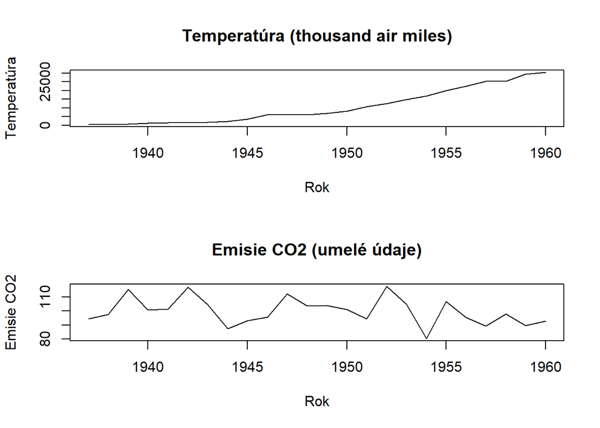

```r
# Nastavenie zrkadla CRAN pre inštaláciu balíkov
options(repos = 'http://cran.us.r-project.org')

# Inštalácia a stiahnutie potrebných balíkov
install.packages("tseries")
library(tseries)
# Načítanie údajov a vytvorenie umelých údajov
temperature_data <- datasets::airmiles
set.seed(123)
co2_data <- rnorm(length(temperature_data), mean = 100, sd = 10)

# Previesť údaje do časového radu
temperature_ts <- ts(temperature_data, start = c(1937), frequency = 1)
co2_ts <- ts(co2_data, start = c(1937), frequency = 1)

# Vizualizácia údajov
par(mfrow = c(2, 1))
plot(temperature_ts, main = "Temperatúra (thousand air miles)", ylab = "Temperatúra", xlab = "Rok")
plot(co2_ts, main = "Emisie CO2 (umelé údaje)", ylab = "Emisie CO2", xlab = "Rok")
```

## Kontrola

Tento kód vykonáva niekoľko úloh súvisiacich s kontrolou stacionarity časových radov a prípravou údajov na ďalšiu analýzu.

```r
# Skontrolujte stacionaritu a v prípade potreby diferencujte
if (adf.test(temperature_ts)$p.value > 0.05) {
  temperature_ts <- na.omit(diff(temperature_ts))
}

if (adf.test(co2_ts)$p.value > 0.05) {
  co2_ts <- na.omit(diff(co2_ts))
}

# Spájanie údajov
climate_data <- data.frame(
  year = start(temperature_ts)[1]:(start(temperature_ts)[1] + length(temperature_ts) - 1),
  temperature = as.numeric(temperature_ts),
  co2_emissions = as.numeric(co2_ts)
)
```

## Analýza údajov

Kontrola stacionarity časových radov a ich prípadná konverzia na stacionárne.

```r
adf_test_temperature <- adf.test(temperature_ts)
adf_test_co2 <- adf.test(co2_ts)

if (adf_test_temperature$p.value > 0.05) {
  temperature_ts <- diff(temperature_ts)
}

if (adf_test_co2$p.value > 0.05) {
  co2_ts <- diff(co2_ts)
}

temperature_ts <- na.omit(temperature_ts)
co2_ts <- na.omit(co2_ts)
```

## Modelovanie a predpovedanie

Tvorba modelu ARIMAX a predpovedanie teploty.

```r
# Zostavte model ARIMAX
model <- arima(climate_data$temperature, order = c(1, 0, 0), xreg = climate_data$co2_emissions)
summary(model)
```

[output not shown]

```r
# Predpovedanie
future_co2 <- rnorm(10, mean = 100, sd = 10)
future_temperature <- predict(model, n.ahead = 10, newxreg = future_co2)
```

## Vizualizacia

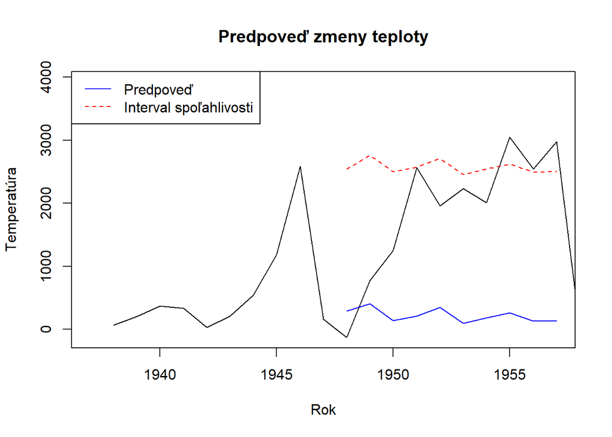

```r
# Vizualizácia predpovede
par(mfrow = c(1, 1))
plot(temperature_ts, xlim = c(1937, 1957), ylim = range(c(temperature_ts, future_temperature$pred)),
     main = "Predpoveď zmeny teploty", ylab = "Temperatúra", xlab = "Rok")
lines(1948:1957, future_temperature$pred, col = "blue")
lines(1948:1957, future_temperature$pred + 2 * future_temperature$se, col = "red", lty = 2)
lines(1948:1957, future_temperature$pred - 2 * future_temperature$se, col = "red", lty = 2)
legend("topleft", legend = c("Predpoveď", "Interval spoľahlivosti"), col = c("blue", "red"), lty = 1:2)
```

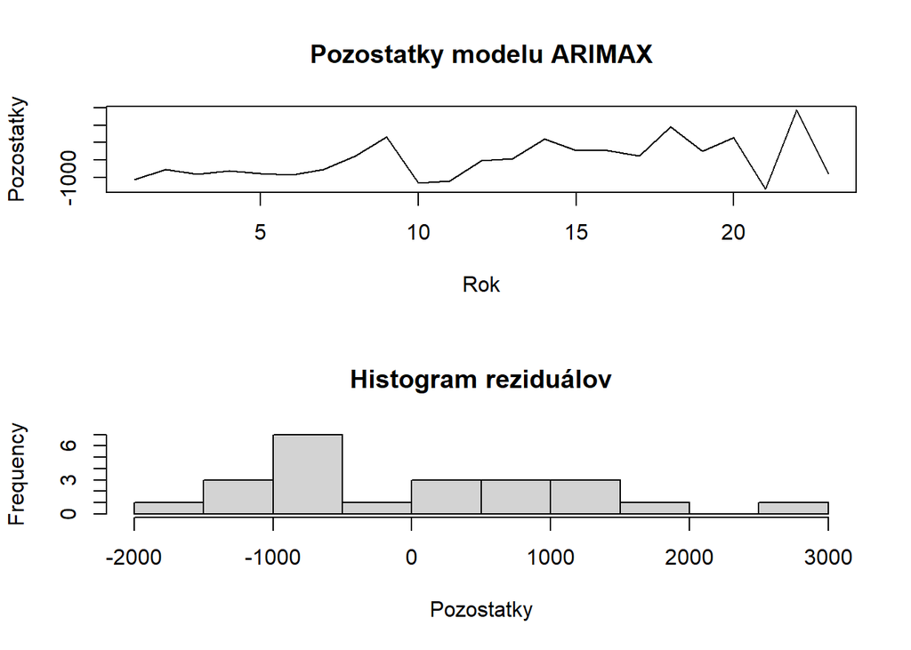

```r
# Vizualizácia zvyškov modelu
par(mfrow = c(2, 1))
plot(residuals(model), main = "Pozostatky modelu ARIMAX", ylab = "Pozostatky", xlab = "Rok")
hist(residuals(model), main = "Histogram reziduálov", xlab = "Pozostatky", breaks = 10)
```

## References

*Forecasting: Principles and Practice (2nd Ed)*. n.d. Accessed June 25, 2024. https://otexts.com/fpp2/.

Wilson, Granville Tunnicliffe. 2016. “Time Series Analysis: Forecasting and Control, 5th Edition, by George E. P. Box, Gwilym M. Jenkins, Gregory C. Reinsel and Greta M. Ljung, 2015. Published by John Wiley and Sons Inc., Hoboken, New Jersey, Pp. 712. ISBN: 978‐1‐118‐67502‐1.” *Journal of Time Series Analysis* 37 (5): 709–11. https://doi.org/10.1111/jtsa.12194.